# Lecture Code: ANOVA Study Design

Engineering Statistics I (MA223)

Dr. Reyes

While the “Coding Cookbook” on the course site gives an overview of all code covered in the class, this document provides the code that accompanies the lecture centering on good study design in the context of comparing a quantitative response across the levels of a particular factor.

## Background

The use of threaded nails has expanded into wood construction because they are believed to have superior performance. However, few tests have been conducted on large nails (3.76 mm diameter and larger). Of particular interest is the amount of force required to pull a nail out of a piece of lumber, known as the withdrawal strength. It is unclear if the type of threading affects the strength of larger nails. The *Journal of Structural Engineering* (2001) reported a study conducted to compare the withdrawal strength of three types of nails — annularly threaded, helically threaded, and smooth. Specifically, investigators were interested in determining if, on average, the withdrawal strength differed among the three types of large nails. The full citation is provided below:

> Rammer DR, Winistorfer SG, and Bender DA. “Withdrawal strength of threaded nails.” *Journal of Structural Engineering*. (2001) 127(4):442-449.

In brief, a sample of 150 nails with a nominal diameter of 3.76 mm (or as close to this as possible) was obtained. Investigators selected 50 nails which were annularly threaded, 50 which were helically threaded, and 50 which were smooth. Each nail was de-greased in a trichloroethane 1-1-1 bath for a minimum of 20 minutes and then air dried for a minimum of 1 hour before being driven into a specimen of Spruce-Pine-Fir. All lumber was conditioned at 20 degrees C and 80% relative humidity for several months. Each nail was driven into the lumber to a depth of 70% of the nail length or thread length, whichever was shorter. No pilot holes were drilled.

The first few records of the data are shown below.

| Withdrawal_Strength | Threading |
| --- | --- |
| 46.151150 | Annular |
| 53.586421 | Annular |
| 41.186140 | Annular |
| 45.992338 | Annular |
| 50.717347 | Annular |
| 63.463791 | Annular |
| 22.435830 | Annular |
| 51.762756 | Annular |
| 55.440892 | Annular |
| 44.095094 | Annular |

[output cut: 140 more lines]

## Graphics

In order to examine our question of interest, which has the form
$$H_0: \mu_1 = \mu_2 = \mu_3 \quad \text{vs.} \quad H_1: \text{at least one mean differs}$$

where $\mu_1$, $\mu_2$ and $\mu_3$ represent the mean withdrawal strength for each type of threaded nail, we want a graphic which shows the location and spread of each of the groups. And, we want to do this in a way which allows for easy comparison. The classical way of doing this is the side-by-side boxplot.

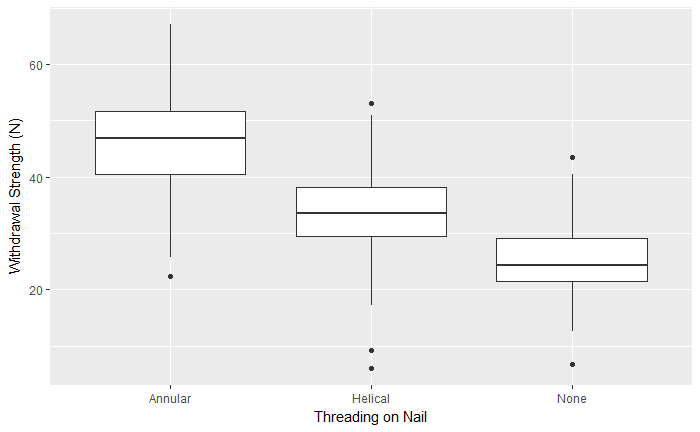

```r
qplot(data = nails,
      x = Threading,
      y = Withdrawal_Strength,
      geom = "boxplot",
      xlab = "Threading on Nail",
      ylab = "Withdrawal Strength (N)")
```

Such a graphic allows us to quickly get a feel for whether there are differences across the groups. It also allows us to compare to determine which, if any, group is superior.

Of course, side-by-side boxplots, while useful for summarizing larger samples can hide the individual values. If you have a smaller sample, you might try a more direct individual value plot (showing the raw data).

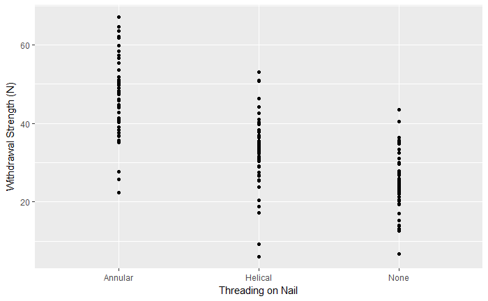

```r
qplot(data = nails,
      x = Threading,
      y = Withdrawal_Strength,
      xlab = "Threading on Nail",
      ylab = "Withdrawal Strength (N)")
```

This gives similar information. The downside to this plot when there are large samples is that the overlap can make it difficult to really see how many points are there. An additional plot, which is nice, is an overlayed density plot. Such a graphic makes use of additional “aesthetics” instead of multiple axes. In order to really make this plot useful, it is helpful to make the fill color transparent (using the `alpha = I(0.5)` option). The `I(0.5)` ensures that you communicate to the program that this is not mapping the variables to the aesthetic but are setting a permanant option.

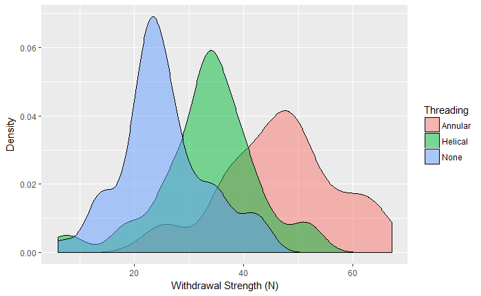

```r
qplot(data = nails,
      x = Withdrawal_Strength,
      fill = Threading,
      alpha = I(0.5),
      geom = "density",
      xlab = "Withdrawal Strength (N)",
      ylab = "Density")
```

There is one last idea we can show graphically. This is the idea of layering multiple graphs together. The following graphic can occasionally be helpful. Here, we have taken the points and “jittered” them a bit so that they do not fall on top of one another. The boxplot is then overlayed on top in order to summarize the distribution.

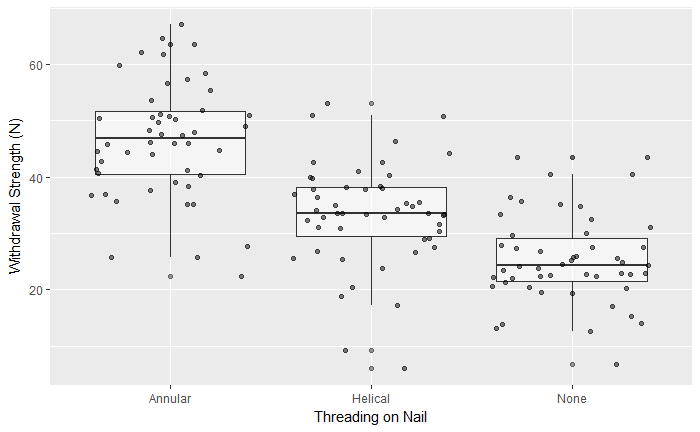

```r
qplot(data = nails,
      x = Threading,
      y = Withdrawal_Strength,
      alpha = I(0.5),
      geom = c("boxplot", "jitter"),
      xlab = "Threading on Nail",
      ylab = "Withdrawal Strength (N)")
```